# Tree shape diversity

```python
import os
import tempfile
cache_dir = tempfile.mkdtemp()
os.environ['XDG_CACHE_HOME'] = cache_dir
import glob
import pickle
import pandas as pd
import numpy as np
import scipy as sp
import seaborn as sns
import matplotlib.pyplot as plt
from matplotlib import cm
from matplotlib.colors import Normalize, to_hex
from svgutils.compose import *
import altair as alt

import utils.trees as ut
import utils.phenotype_colorscales as pc
```

import os import tempfile cache_dir = tempfile.mkdtemp() os.environ['XDG_CACHE_HOME'] = cache_dir import glob import pickle import pandas as pd import numpy as np import scipy as sp import seaborn as sns import matplotlib.pyplot as plt from matplotlib import cm from matplotlib.colors import Normalize, to_hex from svgutils.compose import * import altair as alt import utils.trees as ut import utils.phenotype_colorscales as pc

parameters

```python
results = "results"
ranking_subdir = 'naive_reversions_first'
scale = 20 # must be 5 or 20
metadata_csv = "../../gc_metadata.csv"
outbase = "_ignore/NDS-LB/"
workflow_env_exec = True
```

results = "results" ranking_subdir = 'naive_reversions_first' scale = 20 # must be 5 or 20 metadata_csv = "../../gc_metadata.csv" outbase = "_ignore/NDS-LB/" workflow_env_exec = True

injected-parameters

```python
# Parameters
results = "."
ranking_subdir = "default"
metadata_csv = "gc_metadata.csv"
outbase = "."
workflow_env_exec = True
```

# Parameters results = "." ranking_subdir = "default" metadata_csv = "gc_metadata.csv" outbase = "." workflow_env_exec = True

```python
if workflow_env_exec:
    os.environ['PYTHONHASHSEED'] = '0'
    os.environ['MPLBACKEND'] = 'Agg'
    os.environ['MPLCONFIGDIR'] = '/tmp/matplotlib'
    os.environ["QT_QPA_PLATFORM"] = "offscreen"
    os.environ["XDG_RUNTIME_DIR"] = "/tmp/xdg"
```

if workflow_env_exec: os.environ['PYTHONHASHSEED'] = '0' os.environ['MPLBACKEND'] = 'Agg' os.environ['MPLCONFIGDIR'] = '/tmp/matplotlib' os.environ["QT_QPA_PLATFORM"] = "offscreen" os.environ["XDG_RUNTIME_DIR"] = "/tmp/xdg"

```python
output_dir = f"{outbase}/{ranking_subdir}"
if not os.path.exists(output_dir):
    os.makedirs(output_dir)
```

output_dir = f"{outbase}/{ranking_subdir}" if not os.path.exists(output_dir): os.makedirs(output_dir)

## Load GC trees and constuct a data frame of statistics

```python
# results = "../nextflow/results"
metadata = pd.read_csv(metadata_csv, index_col=0)
metadata.query("(strain == 'wt') & (cell_type == 'GC') & (imm_duration != 'w10')", inplace=True)
metadata
```

# results = "../nextflow/results" metadata = pd.read_csv(metadata_csv, index_col=0) metadata.query("(strain == 'wt') & (cell_type == 'GC') & (imm_duration != 'w10')", inplace=True) metadata

| uid | ngs_id | imm_duration | mouse | gc | strain | node | cell_type | plate | hc_barcode | lc_barcode | row | col |
| --- | --- | --- | --- | --- | --- | --- | --- | --- | --- | --- | --- | --- |
| D15_M1_GC1 | PR-2-01 | d15 | 1 | 1 | wt | RP | GC | 2 | 9 | 9 | A.B.C.D.E.F.G.H | 1.2.3.4.5.6.7.8.9.10.11.12 |
| D15_M1_GC2 | PR-2-01 | d15 | 1 | 2 | wt | RI | GC | 3 | 2 | 1 | A.B.C.D.E.F.G.H | 1.2.3.4.5.6.7.8.9.10.11.12 |
| D15_M1_GC3 | PR-2-01 | d15 | 1 | 3 | wt | LI | GC | 4 | 14 | 2 | A.B.C.D.E.F.G.H | 1.2.3.4.5.6.7.8.9.10.11.12 |
| D15_M2_GC4 | PR-2-01 | d15 | 2 | 4 | wt | RP | GC | 5 | 10 | 11 | A.B.C.D.E.F.G.H | 1.2.3.4.5.6.7.8.9.10.11.12 |
| D15_M3_GC5 | PR-2-01 | d15 | 3 | 5 | wt | RP | GC | 6 | 7 | 4 | A.B.C.D.E.F.G.H | 1.2.3.4.5.6.7.8.9.10.11.12 |
| ... | ... | ... | ... | ... | ... | ... | ... | ... | ... | ... | ... | ... |
| D20_M24_GC115 | PR-1-04 | d20 | 24 | 115 | wt | RP | GC | 72 | 16 | 16 | A.B.C.D.E.F.G.H | 1.2.3.4.5.6.7.8.9.10.11.12 |
| D20_M25_GC116 | PR-1-02 | d20 | 25 | 116 | wt | RP | GC | 65 | 8 | 8 | A.B.C.D.E.F.G.H | 1.2.3.4.5.6.7.8.9.10.11.12 |
| D20_M25_GC117 | PR-1-03 | d20 | 25 | 117 | wt | RP | GC | 68 | 9 | 9 | A.B.C.D.E.F.G.H | 1.2.3.4.5.6.7.8.9.10.11.12 |
| D20_M25_GC118 | PR-1-08 | d20 | 25 | 118 | wt | RP | GC | 66 | 15 | 15 | A.B.C.D.E.F.G.H | 1.2.3.4.5.6.7.8.9.10.11.12 |
| D20_M25_GC119 | PR-1-08 | d20 | 25 | 119 | wt | RP | GC | 67 | 16 | 16 | A.B.C.D.E.F.G.H | 1.2.3.4.5.6.7.8.9.10.11.12 |

119 rows × 12 columns

```python
len(metadata.index.unique())
```

len(metadata.index.unique())

```
119
```

```python
metadata.imm_duration.value_counts()
```

metadata.imm_duration.value_counts()

```
imm_duration
d20    67
d15    52
Name: count, dtype: int64
```

```python
trees = ut.load_trees(metadata, results, ranking_subdir)
len(trees)
```

trees = ut.load_trees(metadata, results, ranking_subdir) len(trees)

```
119
```

```python
stat = "REI"
# taus = np.logspace(-2, 0, 10)
taus = np.linspace(0.05, 1, 20)
# taus = [0.05, 0.1, 1]

# stat = "LBI"
# taus = np.logspace(-1, 1, 50)
```

stat = "REI" # taus = np.logspace(-2, 0, 10) taus = np.linspace(0.05, 1, 20) # taus = [0.05, 0.1, 1] # stat = "LBI" # taus = np.logspace(-1, 1, 50)

```python
df = pd.DataFrame()

row = 0
for tau in taus:
    for key, tree in trees.items():
        pr, mouse, gc = key.split("_")
        mouse = mouse.lstrip("mouse")

        ut.burst_stat(tree, stat, tau)

        gc = gc.lstrip("GC")
        df.loc[row, "uid"] = key
        df.loc[row, "τ"] = tau
        df.loc[row, "ngs_id"] = metadata.ngs_id[key]
        df.loc[row, "mouse"] = str(metadata.mouse[key])
        df.loc[row, "GC"] = str(metadata.gc[key])
        df.loc[row, "time"] = metadata.imm_duration[key]

        abundances = np.array([node.abundance for node in tree.tree.traverse()])

        if len(tree.tree.children) == 1:
            print(f"NOTE: tree {key} has only one root clade")
        root = tree.tree

        clade_sizes = [sum(node.abundance for node in child.traverse()) for child in root.children]
        df.loc[row, "cells sampled"] = sum(abundances)
        df.loc[row, "normalized dominance score"] = max(clade_sizes) / sum(clade_sizes)
        df.loc[row, f"maximum {stat}"] = np.nanmax([getattr(node, stat) for node in tree.tree.traverse()])

        # note: additive delta_bind for now
        delta_bind_dat = []
        for node in tree.tree.traverse():
            if not np.isnan(node.delta_bind):
                for _ in range(node.abundance):
                    delta_bind_dat.append(node.delta_bind)
        df.loc[row, "max Δaffinity"] = np.nanmax(delta_bind_dat)
        df.loc[row, "95th percentile Δaffinity"] = np.percentile(delta_bind_dat, 95)
        df.loc[row, "mean Δaffinity"] = np.nanmean(delta_bind_dat)
        df.loc[row, "median Δaffinity"] = np.nanmedian(delta_bind_dat)

        max_stat_idx = np.nanargmax([getattr(node, stat) for node in tree.tree.traverse()])
        df.loc[row, f"id of max {stat} node"] = [node.name for node in tree.tree.traverse()][max_stat_idx]
        df.loc[row, f"mutations in max {stat} node"] = [node.aa_substitutions for node in tree.tree.traverse()][max_stat_idx]
        df.loc[row, f"Δaffinity of max {stat} node"] = [node.delta_bind for node in tree.tree.traverse()][max_stat_idx]
        df.loc[row, f"ΔΔaffinity of max {stat} node"] = [node.delta_bind - (node.up.delta_bind if node.up is not None else 0) for node in tree.tree.traverse()][max_stat_idx]
        df.loc[row, f"max {stat} node is root"] = max_stat_idx == 0

        row += 1

df
```

df = pd.DataFrame() row = 0 for tau in taus: for key, tree in trees.items(): pr, mouse, gc = key.split("_") mouse = mouse.lstrip("mouse") ut.burst_stat(tree, stat, tau) gc = gc.lstrip("GC") df.loc[row, "uid"] = key df.loc[row, "τ"] = tau df.loc[row, "ngs_id"] = metadata.ngs_id[key] df.loc[row, "mouse"] = str(metadata.mouse[key]) df.loc[row, "GC"] = str(metadata.gc[key]) df.loc[row, "time"] = metadata.imm_duration[key] abundances = np.array([node.abundance for node in tree.tree.traverse()]) if len(tree.tree.children) == 1: print(f"NOTE: tree {key} has only one root clade") root = tree.tree clade_sizes = [sum(node.abundance for node in child.traverse()) for child in root.children] df.loc[row, "cells sampled"] = sum(abundances) df.loc[row, "normalized dominance score"] = max(clade_sizes) / sum(clade_sizes) df.loc[row, f"maximum {stat}"] = np.nanmax([getattr(node, stat) for node in tree.tree.traverse()]) # note: additive delta_bind for now delta_bind_dat = [] for node in tree.tree.traverse(): if not np.isnan(node.delta_bind): for _ in range(node.abundance): delta_bind_dat.append(node.delta_bind) df.loc[row, "max Δaffinity"] = np.nanmax(delta_bind_dat) df.loc[row, "95th percentile Δaffinity"] = np.percentile(delta_bind_dat, 95) df.loc[row, "mean Δaffinity"] = np.nanmean(delta_bind_dat) df.loc[row, "median Δaffinity"] = np.nanmedian(delta_bind_dat) max_stat_idx = np.nanargmax([getattr(node, stat) for node in tree.tree.traverse()]) df.loc[row, f"id of max {stat} node"] = [node.name for node in tree.tree.traverse()][max_stat_idx] df.loc[row, f"mutations in max {stat} node"] = [node.aa_substitutions for node in tree.tree.traverse()][max_stat_idx] df.loc[row, f"Δaffinity of max {stat} node"] = [node.delta_bind for node in tree.tree.traverse()][max_stat_idx] df.loc[row, f"ΔΔaffinity of max {stat} node"] = [node.delta_bind - (node.up.delta_bind if node.up is not None else 0) for node in tree.tree.traverse()][max_stat_idx] df.loc[row, f"max {stat} node is root"] = max_stat_idx == 0 row += 1 df

```
NOTE: tree D20_M20_GC61 has only one root clade
NOTE: tree D20_M20_GC62 has only one root clade
NOTE: tree D20_M20_GC64 has only one root clade
NOTE: tree D20_M21_GC71 has only one root clade
NOTE: tree D20_M22_GC90 has only one root clade
```

```
NOTE: tree D20_M22_GC97 has only one root clade
NOTE: tree D20_M23_GC106 has only one root clade
```

```
NOTE: tree D20_M20_GC61 has only one root clade
NOTE: tree D20_M20_GC62 has only one root clade
NOTE: tree D20_M20_GC64 has only one root clade
NOTE: tree D20_M21_GC71 has only one root clade
```

```
NOTE: tree D20_M22_GC90 has only one root clade
NOTE: tree D20_M22_GC97 has only one root clade
NOTE: tree D20_M23_GC106 has only one root clade
```

```
NOTE: tree D20_M20_GC61 has only one root clade
NOTE: tree D20_M20_GC62 has only one root clade
NOTE: tree D20_M20_GC64 has only one root clade
NOTE: tree D20_M21_GC71 has only one root clade
NOTE: tree D20_M22_GC90 has only one root clade
NOTE: tree D20_M22_GC97 has only one root clade
```

```
NOTE: tree D20_M23_GC106 has only one root clade
```

```
NOTE: tree D20_M20_GC61 has only one root clade
NOTE: tree D20_M20_GC62 has only one root clade
NOTE: tree D20_M20_GC64 has only one root clade
NOTE: tree D20_M21_GC71 has only one root clade
NOTE: tree D20_M22_GC90 has only one root clade
```

```
NOTE: tree D20_M22_GC97 has only one root clade
NOTE: tree D20_M23_GC106 has only one root clade
```

```
NOTE: tree D20_M20_GC61 has only one root clade
NOTE: tree D20_M20_GC62 has only one root clade
NOTE: tree D20_M20_GC64 has only one root clade
NOTE: tree D20_M21_GC71 has only one root clade
```

```
NOTE: tree D20_M22_GC90 has only one root clade
NOTE: tree D20_M22_GC97 has only one root clade
NOTE: tree D20_M23_GC106 has only one root clade
```

```
NOTE: tree D20_M20_GC61 has only one root clade
NOTE: tree D20_M20_GC62 has only one root clade
NOTE: tree D20_M20_GC64 has only one root clade
NOTE: tree D20_M21_GC71 has only one root clade
```

```
NOTE: tree D20_M22_GC90 has only one root clade
NOTE: tree D20_M22_GC97 has only one root clade
NOTE: tree D20_M23_GC106 has only one root clade
```

```
NOTE: tree D20_M20_GC61 has only one root clade
NOTE: tree D20_M20_GC62 has only one root clade
NOTE: tree D20_M20_GC64 has only one root clade
NOTE: tree D20_M21_GC71 has only one root clade
```

```
NOTE: tree D20_M22_GC90 has only one root clade
NOTE: tree D20_M22_GC97 has only one root clade
NOTE: tree D20_M23_GC106 has only one root clade
```

```
NOTE: tree D20_M20_GC61 has only one root clade
NOTE: tree D20_M20_GC62 has only one root clade
NOTE: tree D20_M20_GC64 has only one root clade
NOTE: tree D20_M21_GC71 has only one root clade
```

```
NOTE: tree D20_M22_GC90 has only one root clade
NOTE: tree D20_M22_GC97 has only one root clade
NOTE: tree D20_M23_GC106 has only one root clade
```

```
NOTE: tree D20_M20_GC61 has only one root clade
NOTE: tree D20_M20_GC62 has only one root clade
NOTE: tree D20_M20_GC64 has only one root clade
NOTE: tree D20_M21_GC71 has only one root clade
```

```
NOTE: tree D20_M22_GC90 has only one root clade
NOTE: tree D20_M22_GC97 has only one root clade
NOTE: tree D20_M23_GC106 has only one root clade
```

```
NOTE: tree D20_M20_GC61 has only one root clade
NOTE: tree D20_M20_GC62 has only one root clade
NOTE: tree D20_M20_GC64 has only one root clade
NOTE: tree D20_M21_GC71 has only one root clade
```

```
NOTE: tree D20_M22_GC90 has only one root clade
NOTE: tree D20_M22_GC97 has only one root clade
NOTE: tree D20_M23_GC106 has only one root clade
```

```
NOTE: tree D20_M20_GC61 has only one root clade
NOTE: tree D20_M20_GC62 has only one root clade
NOTE: tree D20_M20_GC64 has only one root clade
NOTE: tree D20_M21_GC71 has only one root clade
```

```
NOTE: tree D20_M22_GC90 has only one root clade
NOTE: tree D20_M22_GC97 has only one root clade
NOTE: tree D20_M23_GC106 has only one root clade
```

```
NOTE: tree D20_M20_GC61 has only one root clade
NOTE: tree D20_M20_GC62 has only one root clade
NOTE: tree D20_M20_GC64 has only one root clade
NOTE: tree D20_M21_GC71 has only one root clade
```

```
NOTE: tree D20_M22_GC90 has only one root clade
NOTE: tree D20_M22_GC97 has only one root clade
NOTE: tree D20_M23_GC106 has only one root clade
```

```
NOTE: tree D20_M20_GC61 has only one root clade
NOTE: tree D20_M20_GC62 has only one root clade
NOTE: tree D20_M20_GC64 has only one root clade
NOTE: tree D20_M21_GC71 has only one root clade
```

```
NOTE: tree D20_M22_GC90 has only one root clade
NOTE: tree D20_M22_GC97 has only one root clade
NOTE: tree D20_M23_GC106 has only one root clade
```

```
NOTE: tree D20_M20_GC61 has only one root clade
NOTE: tree D20_M20_GC62 has only one root clade
NOTE: tree D20_M20_GC64 has only one root clade
NOTE: tree D20_M21_GC71 has only one root clade
```

```
NOTE: tree D20_M22_GC90 has only one root clade
NOTE: tree D20_M22_GC97 has only one root clade
NOTE: tree D20_M23_GC106 has only one root clade
```

```
NOTE: tree D20_M20_GC61 has only one root clade
NOTE: tree D20_M20_GC62 has only one root clade
NOTE: tree D20_M20_GC64 has only one root clade
NOTE: tree D20_M21_GC71 has only one root clade
```

```
NOTE: tree D20_M22_GC90 has only one root clade
NOTE: tree D20_M22_GC97 has only one root clade
NOTE: tree D20_M23_GC106 has only one root clade
```

```
NOTE: tree D20_M20_GC61 has only one root clade
NOTE: tree D20_M20_GC62 has only one root clade
NOTE: tree D20_M20_GC64 has only one root clade
NOTE: tree D20_M21_GC71 has only one root clade
```

```
NOTE: tree D20_M22_GC90 has only one root clade
NOTE: tree D20_M22_GC97 has only one root clade
NOTE: tree D20_M23_GC106 has only one root clade
```

```
NOTE: tree D20_M20_GC61 has only one root clade
NOTE: tree D20_M20_GC62 has only one root clade
NOTE: tree D20_M20_GC64 has only one root clade
NOTE: tree D20_M21_GC71 has only one root clade
```

```
NOTE: tree D20_M22_GC90 has only one root clade
NOTE: tree D20_M22_GC97 has only one root clade
NOTE: tree D20_M23_GC106 has only one root clade
```

```
NOTE: tree D20_M20_GC61 has only one root clade
NOTE: tree D20_M20_GC62 has only one root clade
NOTE: tree D20_M20_GC64 has only one root clade
NOTE: tree D20_M21_GC71 has only one root clade
```

```
NOTE: tree D20_M22_GC90 has only one root clade
NOTE: tree D20_M22_GC97 has only one root clade
NOTE: tree D20_M23_GC106 has only one root clade
```

```
NOTE: tree D20_M20_GC61 has only one root clade
NOTE: tree D20_M20_GC62 has only one root clade
NOTE: tree D20_M20_GC64 has only one root clade
NOTE: tree D20_M21_GC71 has only one root clade
```

```
NOTE: tree D20_M22_GC90 has only one root clade
NOTE: tree D20_M22_GC97 has only one root clade
NOTE: tree D20_M23_GC106 has only one root clade
```

```
NOTE: tree D20_M20_GC61 has only one root clade
NOTE: tree D20_M20_GC62 has only one root clade
NOTE: tree D20_M20_GC64 has only one root clade
NOTE: tree D20_M21_GC71 has only one root clade
```

```
NOTE: tree D20_M22_GC90 has only one root clade
NOTE: tree D20_M22_GC97 has only one root clade
NOTE: tree D20_M23_GC106 has only one root clade
```

|  | uid | τ | ngs_id | mouse | GC | time | cells sampled | normalized dominance score | maximum REI | max Δaffinity | 95th percentile Δaffinity | mean Δaffinity | median Δaffinity | id of max REI node | mutations in max REI node | Δaffinity of max REI node | ΔΔaffinity of max REI node | max REI node is root |
| --- | --- | --- | --- | --- | --- | --- | --- | --- | --- | --- | --- | --- | --- | --- | --- | --- | --- | --- |
| 0 | D15_M1_GC1 | 0.05 | PR-2-01 | 1 | 1 | d15 | 67.0 | 0.462687 | 0.062726 | 1.57098 | 1.323038 | 0.497280 | 0.773400 | seq36 | A105(H)G S109(L)R | 1.24129 | 0.79500 | False |
| 1 | D15_M1_GC2 | 0.05 | PR-2-01 | 1 | 2 | d15 | 79.0 | 0.435897 | 0.028576 | 1.44539 | 1.299505 | 0.381382 | 0.397360 | seq41 | D107(H)E | 0.20896 | 0.20896 | False |
| 2 | D15_M1_GC3 | 0.05 | PR-2-01 | 1 | 3 | d15 | 73.0 | 0.506849 | 0.048843 | 1.96260 | 1.291822 | 0.504928 | 0.535100 | seq41 | A105(H)G | 0.44629 | 0.44629 | False |
| 3 | D15_M2_GC4 | 0.05 | PR-2-01 | 2 | 4 | d15 | 44.0 | 0.340909 | 0.093466 | 0.88793 | 0.801909 | 0.092011 | 0.287630 | seq8 | A105(H)G | 0.44629 | 0.44629 | False |
| 4 | D15_M3_GC5 | 0.05 | PR-2-01 | 3 | 5 | d15 | 78.0 | 0.213333 | 0.040110 | 1.59914 | 1.107394 | -0.214632 | 0.000000 | naive |  | 0.00000 | 0.00000 | True |
| ... | ... | ... | ... | ... | ... | ... | ... | ... | ... | ... | ... | ... | ... | ... | ... | ... | ... | ... |
| 2375 | D20_M24_GC115 | 1.00 | PR-1-04 | 24 | 115 | d20 | 85.0 | 0.882353 | 1.000000 | 1.94591 | 1.830034 | 1.094204 | 1.046480 | naive |  | 0.00000 | 0.00000 | True |
| 2376 | D20_M25_GC116 | 1.00 | PR-1-02 | 25 | 116 | d20 | 78.0 | 0.884615 | 1.000000 | 2.38422 | 1.655125 | 0.784909 | 1.105020 | naive |  | 0.00000 | 0.00000 | True |
| 2377 | D20_M25_GC117 | 1.00 | PR-1-03 | 25 | 117 | d20 | 76.0 | 0.407895 | 1.000000 | 1.78818 | 1.578093 | 0.632779 | 0.608315 | naive |  | 0.00000 | 0.00000 | True |
| 2378 | D20_M25_GC118 | 1.00 | PR-1-08 | 25 | 118 | d20 | 70.0 | 0.985714 | 1.000000 | 1.42049 | 1.351937 | 0.288105 | 0.492355 | naive |  | 0.00000 | 0.00000 | True |
| 2379 | D20_M25_GC119 | 1.00 | PR-1-08 | 25 | 119 | d20 | 81.0 | 0.580247 | 1.000000 | 1.68377 | 1.527660 | 0.582019 | 0.700545 | naive |  | 0.00000 | 0.00000 | True |

2380 rows × 18 columns

```python
df.groupby("τ")[f"max {stat} node is root"].agg(lambda group: group.astype(int).sum() / len(group)).plot(xlabel="τ", ylabel=f"fraction GCs with root as max {stat} node", figsize=(5, 4));
# plt.xscale("log")
```

df.groupby("τ")[f"max {stat} node is root"].agg(lambda group: group.astype(int).sum() / len(group)).plot(xlabel="τ", ylabel=f"fraction GCs with root as max {stat} node", figsize=(5, 4)); # plt.xscale("log")

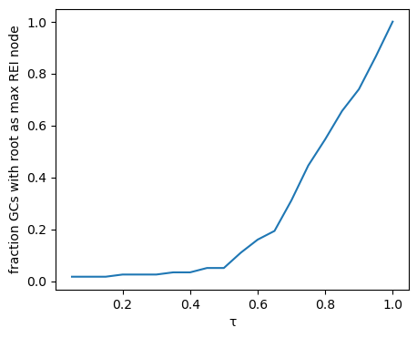

```python
taus
```

taus

```
array([0.05, 0.1 , 0.15, 0.2 , 0.25, 0.3 , 0.35, 0.4 , 0.45, 0.5 , 0.55,
       0.6 , 0.65, 0.7 , 0.75, 0.8 , 0.85, 0.9 , 0.95, 1.  ])
```

```python
g = sns.relplot(data=df.loc[df.τ.isin(taus)], x=f"Δaffinity of max {stat} node", y="median Δaffinity", col="τ",
                col_wrap=5, hue="max REI node is root", height=2, s=10, legend=False,
                facet_kws={"sharex": False, "sharey": True})
for tau, ax in zip(taus, g.axes):
    ax.set_title(f"τ = {tau:.2f}")
plt.tight_layout()
plt.show()
```

g = sns.relplot(data=df.loc[df.τ.isin(taus)], x=f"Δaffinity of max {stat} node", y="median Δaffinity", col="τ", col_wrap=5, hue="max REI node is root", height=2, s=10, legend=False, facet_kws={"sharex": False, "sharey": True}) for tau, ax in zip(taus, g.axes): ax.set_title(f"τ = {tau:.2f}") plt.tight_layout() plt.show()

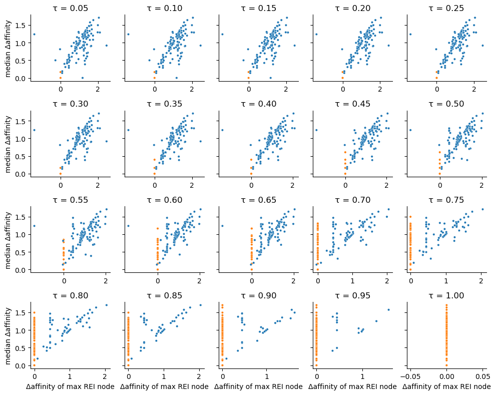

```python
sns.scatterplot(data=df.loc[df.τ == taus[0]], x="cells sampled", y=f"median Δaffinity", hue="mouse", style="ngs_id", legend=False)
plt.show()

sns.scatterplot(data=df.loc[df.τ == taus[0]], x="cells sampled", y=f"max Δaffinity", hue="mouse", style="ngs_id", legend=False)
plt.show()
```

sns.scatterplot(data=df.loc[df.τ == taus[0]], x="cells sampled", y=f"median Δaffinity", hue="mouse", style="ngs_id", legend=False) plt.show() sns.scatterplot(data=df.loc[df.τ == taus[0]], x="cells sampled", y=f"max Δaffinity", hue="mouse", style="ngs_id", legend=False) plt.show()

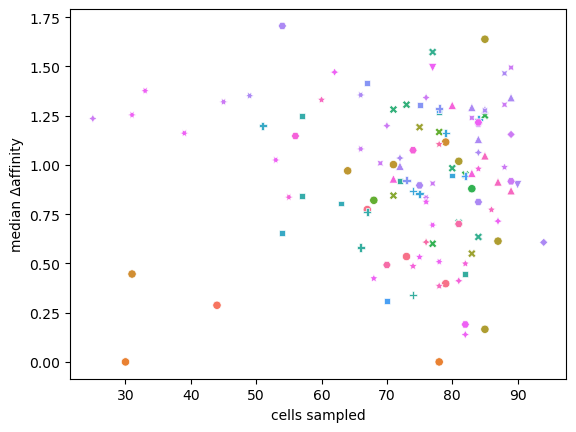

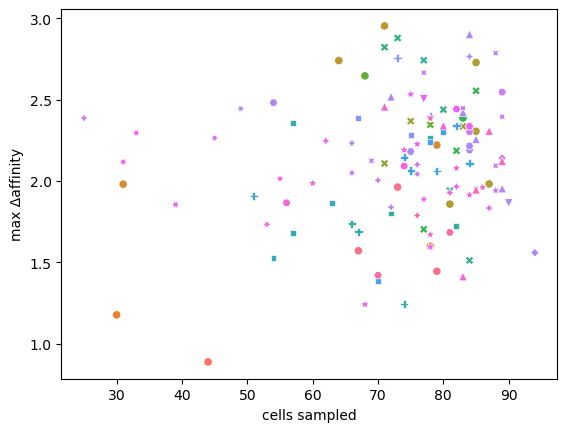

```python
g = sns.relplot(data=df.loc[df.τ.isin(taus)], x="cells sampled", y=f"maximum REI", col="τ",
                col_wrap=5, hue="max REI node is root", height=2, s=10, legend=False,
                facet_kws={"sharex": True, "sharey": False})
for tau, ax in zip(taus, g.axes):
    ax.set_title(f"τ = {tau:.2f}")
plt.tight_layout()
plt.show()
```

g = sns.relplot(data=df.loc[df.τ.isin(taus)], x="cells sampled", y=f"maximum REI", col="τ", col_wrap=5, hue="max REI node is root", height=2, s=10, legend=False, facet_kws={"sharex": True, "sharey": False}) for tau, ax in zip(taus, g.axes): ax.set_title(f"τ = {tau:.2f}") plt.tight_layout() plt.show()

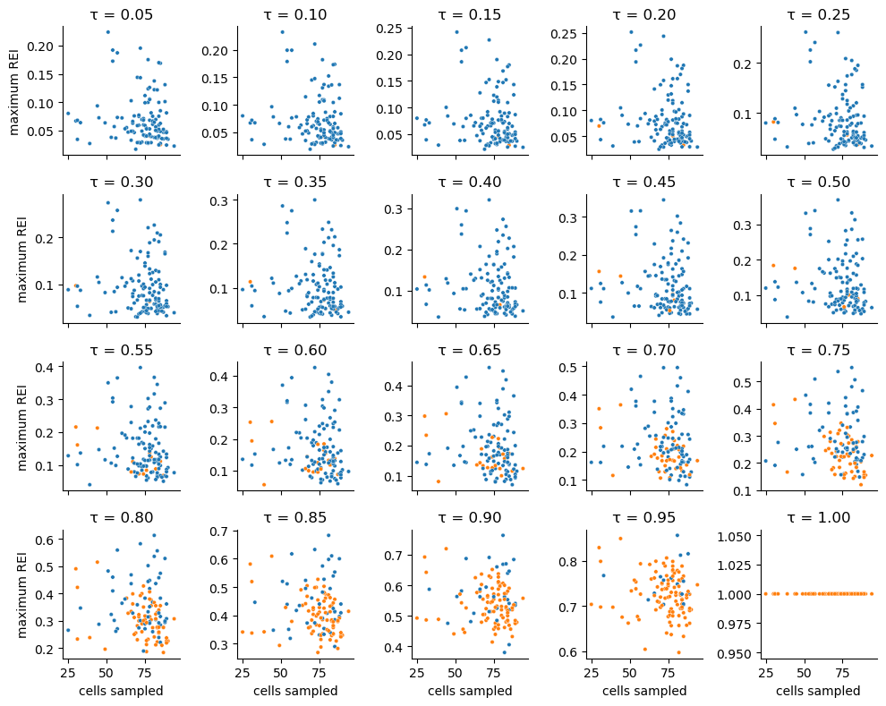

```python
g = sns.relplot(data=df.loc[df.τ.isin(taus)], x=f"maximum REI", y="median Δaffinity", col="τ",
                col_wrap=5, hue="max REI node is root", height=2, s=10, legend=False,
                facet_kws={"sharex": False, "sharey": True})
for tau, ax in zip(taus, g.axes):
    ax.set_title(f"τ = {tau:.2f}")
plt.tight_layout()
plt.show()
```

g = sns.relplot(data=df.loc[df.τ.isin(taus)], x=f"maximum REI", y="median Δaffinity", col="τ", col_wrap=5, hue="max REI node is root", height=2, s=10, legend=False, facet_kws={"sharex": False, "sharey": True}) for tau, ax in zip(taus, g.axes): ax.set_title(f"τ = {tau:.2f}") plt.tight_layout() plt.show()

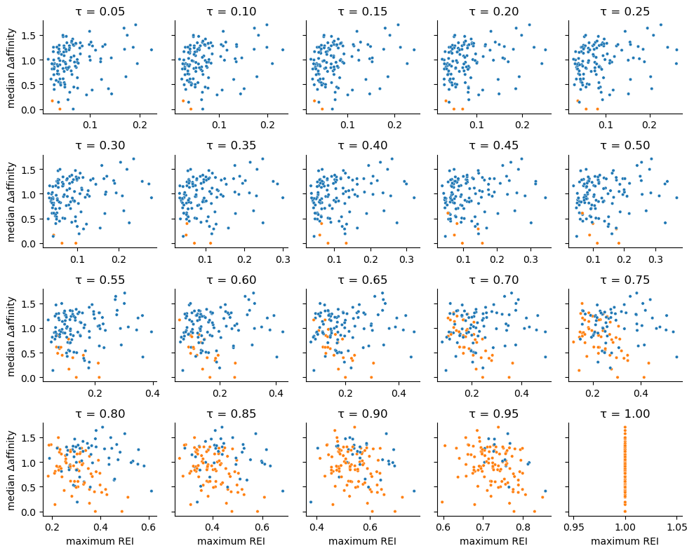

```python
g = sns.relplot(data=df.loc[df.τ.isin(taus)], x=f"maximum REI", y=f"Δaffinity of max {stat} node", col="τ",
                col_wrap=5, hue="max REI node is root", height=2, s=10, legend=False,
                facet_kws={"sharex": False, "sharey": False})
for tau, ax in zip(taus, g.axes):
    ax.set_title(f"τ = {tau:.2f}")
plt.tight_layout()
plt.show()
```

g = sns.relplot(data=df.loc[df.τ.isin(taus)], x=f"maximum REI", y=f"Δaffinity of max {stat} node", col="τ", col_wrap=5, hue="max REI node is root", height=2, s=10, legend=False, facet_kws={"sharex": False, "sharey": False}) for tau, ax in zip(taus, g.axes): ax.set_title(f"τ = {tau:.2f}") plt.tight_layout() plt.show()

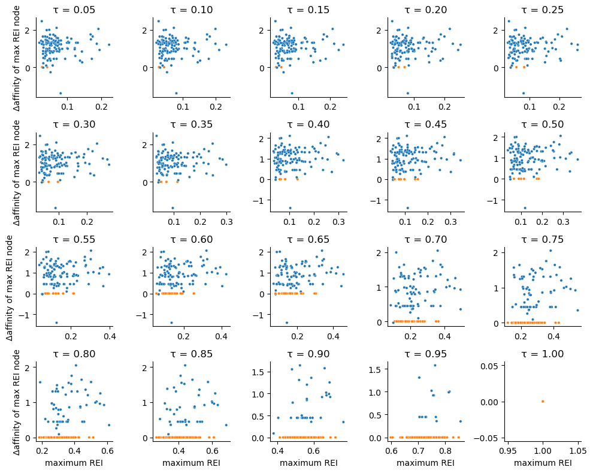

```python
cor_df = pd.DataFrame()
for gc, group_df in df.groupby("τ"):
    ρ_node, p_node = sp.stats.spearmanr(group_df[f"Δaffinity of max {stat} node"], group_df[f"maximum {stat}"])
    ρ_gc, p_gc = sp.stats.spearmanr(group_df[f"median Δaffinity"], group_df[f"maximum {stat}"])
    ρ_aff, p_aff = sp.stats.spearmanr(group_df[f"median Δaffinity"], group_df[f"Δaffinity of max {stat} node"])
    cor_df.loc[gc, "ρ_node"] = ρ_node
    cor_df.loc[gc, "ρ_gc"] = ρ_gc
    cor_df.loc[gc, "p_node"] = p_node
    cor_df.loc[gc, "p_gc"] = p_gc
    cor_df.loc[gc, "ρ_aff"] = ρ_aff
    cor_df.loc[gc, "p_aff"] = p_aff

plt.figure(figsize=(5, 7))
plt.subplot(2, 1, 1)
plt.title(f"correlations with maximum {stat}")
sns.lineplot(data=cor_df, x=cor_df.index, y="ρ_aff", label=f"median Δaffinity Vs Δaffinity of max {stat} node")
sns.lineplot(data=cor_df, x=cor_df.index, y="ρ_gc", label=f"median Δaffinity Vs max {stat}")
sns.lineplot(data=cor_df, x=cor_df.index, y="ρ_node", label=f"Δaffinity of max {stat} node Vs max {stat}")
plt.axhline(0, color="k", ls="--", lw=1)
# plt.xlabel("τ")
plt.ylabel("Spearman ρ")
plt.ylim(-1, 1)
plt.legend()

plt.subplot(2, 1, 2)
sns.lineplot(data=cor_df, x=cor_df.index, y="p_aff")
sns.lineplot(data=cor_df, x=cor_df.index, y="p_gc")
sns.lineplot(data=cor_df, x=cor_df.index, y="p_node")
plt.xlabel("τ")
plt.ylabel("p-value")
plt.yscale("log")
plt.show()
```

cor_df = pd.DataFrame() for gc, group_df in df.groupby("τ"): ρ_node, p_node = sp.stats.spearmanr(group_df[f"Δaffinity of max {stat} node"], group_df[f"maximum {stat}"]) ρ_gc, p_gc = sp.stats.spearmanr(group_df[f"median Δaffinity"], group_df[f"maximum {stat}"]) ρ_aff, p_aff = sp.stats.spearmanr(group_df[f"median Δaffinity"], group_df[f"Δaffinity of max {stat} node"]) cor_df.loc[gc, "ρ_node"] = ρ_node cor_df.loc[gc, "ρ_gc"] = ρ_gc cor_df.loc[gc, "p_node"] = p_node cor_df.loc[gc, "p_gc"] = p_gc cor_df.loc[gc, "ρ_aff"] = ρ_aff cor_df.loc[gc, "p_aff"] = p_aff plt.figure(figsize=(5, 7)) plt.subplot(2, 1, 1) plt.title(f"correlations with maximum {stat}") sns.lineplot(data=cor_df, x=cor_df.index, y="ρ_aff", label=f"median Δaffinity Vs Δaffinity of max {stat} node") sns.lineplot(data=cor_df, x=cor_df.index, y="ρ_gc", label=f"median Δaffinity Vs max {stat}") sns.lineplot(data=cor_df, x=cor_df.index, y="ρ_node", label=f"Δaffinity of max {stat} node Vs max {stat}") plt.axhline(0, color="k", ls="--", lw=1) # plt.xlabel("τ") plt.ylabel("Spearman ρ") plt.ylim(-1, 1) plt.legend() plt.subplot(2, 1, 2) sns.lineplot(data=cor_df, x=cor_df.index, y="p_aff") sns.lineplot(data=cor_df, x=cor_df.index, y="p_gc") sns.lineplot(data=cor_df, x=cor_df.index, y="p_node") plt.xlabel("τ") plt.ylabel("p-value") plt.yscale("log") plt.show()

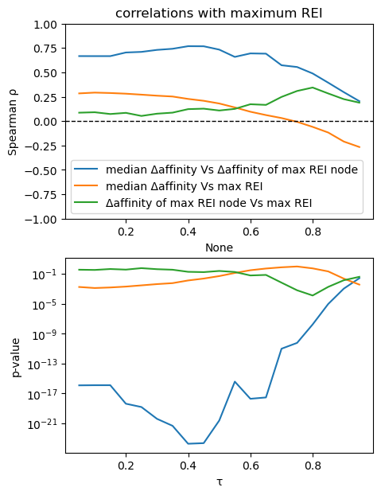

```python
# outcome = "mean Δaffinity"
# outcome = "median Δaffinity"
# outcome = "95th percentile Δaffinity"
outcome = f"Δaffinity of max {stat} node"
# outcome = f"ΔΔaffinity of max {stat} node"
```

# outcome = "mean Δaffinity" # outcome = "median Δaffinity" # outcome = "95th percentile Δaffinity" outcome = f"Δaffinity of max {stat} node" # outcome = f"ΔΔaffinity of max {stat} node"

```python
# tau = taus[np.where(tau_cor_df.ρ > 0, tau_cor_df.p, 1).argmin()]
tau = taus[9]
tau
```

# tau = taus[np.where(tau_cor_df.ρ > 0, tau_cor_df.p, 1).argmin()] tau = taus[9] tau

```
np.float64(0.49999999999999994)
```

Need to recompute tree stats using the chosen $\tau$

```python
for tree in trees.values():
    ut.burst_stat(tree, stat, tau)
```

for tree in trees.values(): ut.burst_stat(tree, stat, tau)

```python
df = df.loc[df["τ"] == tau].sort_values(f"maximum {stat}").reset_index()
df
```

df = df.loc[df["τ"] == tau].sort_values(f"maximum {stat}").reset_index() df

|  | index | uid | τ | ngs_id | mouse | GC | time | cells sampled | normalized dominance score | maximum REI | max Δaffinity | 95th percentile Δaffinity | mean Δaffinity | median Δaffinity | id of max REI node | mutations in max REI node | Δaffinity of max REI node | ΔΔaffinity of max REI node | max REI node is root |
| --- | --- | --- | --- | --- | --- | --- | --- | --- | --- | --- | --- | --- | --- | --- | --- | --- | --- | --- | --- |
| 0 | 1166 | D20_M22_GC96 | 0.5 | PR-1-07 | 22 | 96 | d20 | 39.0 | 0.435897 | 0.038462 | 1.85465 | 1.700965 | 1.005091 | 1.161450 | seq4 | Y88(H)F A105(H)G N108(L)K | 1.35896 | 0.05302 | False |
| 1 | 1159 | D20_M22_GC89 | 0.5 | PR-1-03 | 22 | 89 | d20 | 87.0 | 0.413793 | 0.047593 | 1.83375 | 1.545630 | 0.782702 | 0.714810 | seq33 | Y103(H)F F10(L)L S12(L)T Y42(L)H N108(L)K L116... | 1.46106 | 0.99422 | False |
| 2 | 1158 | D20_M22_GC88 | 0.5 | PR-1-03 | 22 | 88 | d20 | 82.0 | 0.390244 | 0.048780 | 1.96522 | 1.552431 | 0.109996 | 0.138920 | seq15 | T96(H)A P72(L)S N93(L)T L99(L)M L116(L)P | 0.08799 | 0.07656 | False |
| 3 | 1156 | D20_M22_GC86 | 0.5 | PR-1-02 | 22 | 86 | d20 | 76.0 | 0.684211 | 0.050164 | 2.22660 | 1.989688 | 0.534087 | 0.812585 | seq29 | I76(H)F L99(L)W L116(L)P | -0.02546 | 0.00067 | False |
| 4 | 1146 | D20_M21_GC76 | 0.5 | PR-1-05 | 21 | 76 | d20 | 69.0 | 0.768116 | 0.050767 | 2.12465 | 1.787844 | 0.497640 | 1.008670 | 11 | A105(H)G A40(L)G | 1.25043 | 0.00000 | False |
| ... | ... | ... | ... | ... | ... | ... | ... | ... | ... | ... | ... | ... | ... | ... | ... | ... | ... | ... | ... |
| 114 | 1176 | D20_M23_GC106 | 0.5 | PR-1-04 | 23 | 106 | d20 | 83.0 | 1.000000 | 0.312688 | 1.41209 | 1.081766 | 0.828434 | 0.957790 | seq12 | S64(H)T N92(H)K Y42(L)C N108(L)H | 0.95779 | -0.02745 | False |
| 115 | 1110 | D15_M16_GC40 | 0.5 | PR-2-04 | 16 | 40 | d15 | 51.0 | 0.862745 | 0.331189 | 1.90813 | 1.403847 | 0.866527 | 1.199390 | seq13 | A105(H)G Y66(L)F S109(L)R | 1.19939 | 0.75310 | False |
| 116 | 1173 | D20_M23_GC103 | 0.5 | PR-1-03 | 23 | 103 | d20 | 81.0 | 0.962963 | 0.332031 | 1.92757 | 1.245264 | 0.520700 | 0.411910 | seq12 | I78(H)L N92(H)T Y42(L)C | 0.35030 | 0.35030 | False |
| 117 | 1105 | D15_M14_GC35 | 0.5 | PR-2-03 | 14 | 35 | d15 | 57.0 | 0.947368 | 0.338584 | 2.35414 | 2.071883 | 1.101941 | 1.250430 | seq7 | A105(H)G A40(L)G | 1.25043 | 0.80414 | False |
| 118 | 1101 | D15_M13_GC31 | 0.5 | PR-2-03 | 13 | 31 | d15 | 72.0 | 0.845070 | 0.368842 | 1.80017 | 1.484965 | 0.820345 | 0.919910 | seq1 | I78(H)F Y42(L)S N108(L)K | 0.91991 | 0.91991 | False |

119 rows × 19 columns

```python
plt.figure(figsize=(4, 3))
sns.regplot(data=df, x=f"maximum {stat}", y=outcome, scatter_kws=dict(s=10))
plt.title(f"τ = {tau:.2f}")
plt.show()

# plt.figure(figsize=(4, 3))
# sns.regplot(data=df.loc[df[outcome] != 0], x=f"maximum {stat}", y=outcome, scatter_kws=dict(s=10), label="no roots")
# plt.title(f"τ = {tau:.2f}")
# plt.legend()
# plt.show()

plt.figure(figsize=(4, 3))
sns.regplot(data=df, x=f"maximum {stat}", y="median Δaffinity", scatter_kws=dict(s=10))
plt.title(f"τ = {tau:.2f}")
plt.show()
```

plt.figure(figsize=(4, 3)) sns.regplot(data=df, x=f"maximum {stat}", y=outcome, scatter_kws=dict(s=10)) plt.title(f"τ = {tau:.2f}") plt.show() # plt.figure(figsize=(4, 3)) # sns.regplot(data=df.loc[df[outcome] != 0], x=f"maximum {stat}", y=outcome, scatter_kws=dict(s=10), label="no roots") # plt.title(f"τ = {tau:.2f}") # plt.legend() # plt.show() plt.figure(figsize=(4, 3)) sns.regplot(data=df, x=f"maximum {stat}", y="median Δaffinity", scatter_kws=dict(s=10)) plt.title(f"τ = {tau:.2f}") plt.show()

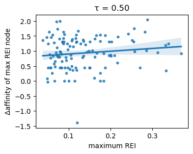

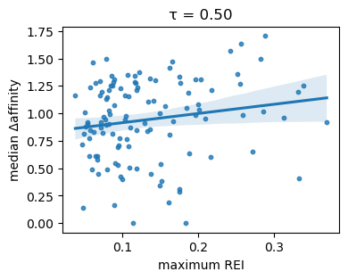

```python
thresh = 0.25
```

thresh = 0.25

```python
df.to_csv(f"{output_dir}/data.csv")
```

df.to_csv(f"{output_dir}/data.csv")

## Rank plot of total GC cell abundance

```python
plt.figure(figsize=(15, 3))
ax = sns.barplot(data=df.sort_values(["ngs_id", "mouse", "cells sampled"]), x="GC", y="cells sampled", #hue="mouse",
                #  hue_order=df.mouse.unique(),
                 legend=False,
                 dodge=False)
plt.xticks(rotation=90)
plt.tight_layout()
plt.savefig(f"{output_dir}/abundances.svg")
plt.show()
```

plt.figure(figsize=(15, 3)) ax = sns.barplot(data=df.sort_values(["ngs_id", "mouse", "cells sampled"]), x="GC", y="cells sampled", #hue="mouse", # hue_order=df.mouse.unique(), legend=False, dodge=False) plt.xticks(rotation=90) plt.tight_layout() plt.savefig(f"{output_dir}/abundances.svg") plt.show()

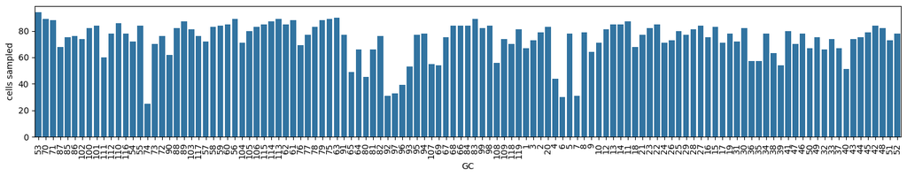

## Plot tree shape stats in a scatter plot, and render some example trees

```python
df
```

df

|  | index | uid | τ | ngs_id | mouse | GC | time | cells sampled | normalized dominance score | maximum REI | max Δaffinity | 95th percentile Δaffinity | mean Δaffinity | median Δaffinity | id of max REI node | mutations in max REI node | Δaffinity of max REI node | ΔΔaffinity of max REI node | max REI node is root |
| --- | --- | --- | --- | --- | --- | --- | --- | --- | --- | --- | --- | --- | --- | --- | --- | --- | --- | --- | --- |
| 0 | 1166 | D20_M22_GC96 | 0.5 | PR-1-07 | 22 | 96 | d20 | 39.0 | 0.435897 | 0.038462 | 1.85465 | 1.700965 | 1.005091 | 1.161450 | seq4 | Y88(H)F A105(H)G N108(L)K | 1.35896 | 0.05302 | False |
| 1 | 1159 | D20_M22_GC89 | 0.5 | PR-1-03 | 22 | 89 | d20 | 87.0 | 0.413793 | 0.047593 | 1.83375 | 1.545630 | 0.782702 | 0.714810 | seq33 | Y103(H)F F10(L)L S12(L)T Y42(L)H N108(L)K L116... | 1.46106 | 0.99422 | False |
| 2 | 1158 | D20_M22_GC88 | 0.5 | PR-1-03 | 22 | 88 | d20 | 82.0 | 0.390244 | 0.048780 | 1.96522 | 1.552431 | 0.109996 | 0.138920 | seq15 | T96(H)A P72(L)S N93(L)T L99(L)M L116(L)P | 0.08799 | 0.07656 | False |
| 3 | 1156 | D20_M22_GC86 | 0.5 | PR-1-02 | 22 | 86 | d20 | 76.0 | 0.684211 | 0.050164 | 2.22660 | 1.989688 | 0.534087 | 0.812585 | seq29 | I76(H)F L99(L)W L116(L)P | -0.02546 | 0.00067 | False |
| 4 | 1146 | D20_M21_GC76 | 0.5 | PR-1-05 | 21 | 76 | d20 | 69.0 | 0.768116 | 0.050767 | 2.12465 | 1.787844 | 0.497640 | 1.008670 | 11 | A105(H)G A40(L)G | 1.25043 | 0.00000 | False |
| ... | ... | ... | ... | ... | ... | ... | ... | ... | ... | ... | ... | ... | ... | ... | ... | ... | ... | ... | ... |
| 114 | 1176 | D20_M23_GC106 | 0.5 | PR-1-04 | 23 | 106 | d20 | 83.0 | 1.000000 | 0.312688 | 1.41209 | 1.081766 | 0.828434 | 0.957790 | seq12 | S64(H)T N92(H)K Y42(L)C N108(L)H | 0.95779 | -0.02745 | False |
| 115 | 1110 | D15_M16_GC40 | 0.5 | PR-2-04 | 16 | 40 | d15 | 51.0 | 0.862745 | 0.331189 | 1.90813 | 1.403847 | 0.866527 | 1.199390 | seq13 | A105(H)G Y66(L)F S109(L)R | 1.19939 | 0.75310 | False |
| 116 | 1173 | D20_M23_GC103 | 0.5 | PR-1-03 | 23 | 103 | d20 | 81.0 | 0.962963 | 0.332031 | 1.92757 | 1.245264 | 0.520700 | 0.411910 | seq12 | I78(H)L N92(H)T Y42(L)C | 0.35030 | 0.35030 | False |
| 117 | 1105 | D15_M14_GC35 | 0.5 | PR-2-03 | 14 | 35 | d15 | 57.0 | 0.947368 | 0.338584 | 2.35414 | 2.071883 | 1.101941 | 1.250430 | seq7 | A105(H)G A40(L)G | 1.25043 | 0.80414 | False |
| 118 | 1101 | D15_M13_GC31 | 0.5 | PR-2-03 | 13 | 31 | d15 | 72.0 | 0.845070 | 0.368842 | 1.80017 | 1.484965 | 0.820345 | 0.919910 | seq1 | I78(H)F Y42(L)S N108(L)K | 0.91991 | 0.91991 | False |

119 rows × 19 columns

```python
pc
```

pc

```
<module 'utils.phenotype_colorscales' from '/fh/fast/matsen_e/shared/replay/pipeline-cache/d3/1ee57a4dd94f4f450fcb7b2312a558/utils/phenotype_colorscales.py'>
```

```python
outcome
```

outcome

```
'Δaffinity of max REI node'
```

```python
# stat cmap
cmap = "viridis"

vmin = min(getattr(node, stat) for tree in trees.values() for node in tree.tree.traverse())
vmax = max(getattr(node, stat) for tree in trees.values() for node in tree.tree.traverse())
xmargin=0.05
ymargin=0.03
xticks = [0.25, 0.5, 0.75, 1.0]
yticks = [0.05, 0.1, 0.15, 0.2, 0.25, 0.3, 0.35]
min_size = df["cells sampled"].min()
max_size = df["cells sampled"].max()
print(min_size, max_size)
# Set up a common normalization for sizes
size_norm = Normalize(vmin=min_size, vmax=max_size)

size_range = (10, 100)

# legend_sizes = [min_size, (min_size + max_size) / 2, max_size]
# legend_markers = [Line2D([0], [0], marker='o', color='w', label=f'{int(size)} cells',
#                          markersize=(20 + (size - min_size) / (max_size - min_size) * 180),
#                          markerfacecolor='gray', markeredgecolor='gray')
#                   for size in legend_sizes]

# size_range = (min_cells_sampled, max_cells_sampled)


for time, time_df in df.groupby("time"):
    print(time, flush=True)

    time_df_mouse_sorted = time_df.copy()
    time_df_mouse_sorted["mouse"] = time_df_mouse_sorted["mouse"].astype(int)
    time_df_mouse_sorted.sort_values("mouse", inplace=True)
    time_df_mouse_sorted["mouse"] = time_df_mouse_sorted["mouse"].astype(str)

    fig, (ax1, ax2, ax3) = plt.subplots(1, 3, figsize=(18,3.5), sharey=True, sharex=True)
    # fig, (ax1, ax2, ax3) = plt.subplots(1, 3, sharey=True, sharex=True)
    sns.scatterplot(data=time_df_mouse_sorted,
                    x="normalized dominance score",
                    y=f"maximum {stat}",
                    hue="mouse",
                    size="cells sampled",
                    sizes=size_range,
                    # size_norm=size_norm,
                    # style="time",
                    clip_on=False,
                    alpha=0.9,
                    legend="brief",
                    size_norm=size_norm,
                    ax=ax1)

    # ax1.legend(handles=legend_markers, title="mouse", loc='upper right', bbox_to_anchor=(1, 1))
    # # Get the existing hue legend and add it
    # handles, labels = ax1.get_legend_handles_labels()
    # ax1.legend(handles=handles + legend_markers, labels=labels + [f'{int(size)} cells' for size in legend_sizes],
    #        title="Outcome & Cells Sampled", loc='upper right', bbox_to_anchor=(1, 1))

    ax1.legend(loc='upper left', bbox_to_anchor=(1, 1), frameon=False, ncol=2)
    # ax1.legend(loc='upper left', frameon=True, ncol=3, fontsize=8)
    # ax1.legend(frameon=False)
    # sns.move_legend(ax1, "upper left", bbox_to_anchor=(1, 1))

    ax2.set_title("median Δaffinity")
    sns.scatterplot(data=time_df_mouse_sorted,
                    x="normalized dominance score",
                    y=f"maximum {stat}",
                    hue="median Δaffinity",
                    size="cells sampled",
                    sizes=size_range,
                    # style="time",
                    clip_on=False,
                    alpha=0.9,
                    palette=pc.affinity_trees.cmap, hue_norm=pc.affinity_trees.norm,
                    legend="brief",
                    size_norm=size_norm,
                    ax=ax2)
    ax2.legend(loc='upper left', bbox_to_anchor=(1, 1), frameon=False)

    ax3.set_title(outcome)
    sns.scatterplot(data=time_df_mouse_sorted,
                    x="normalized dominance score",
                    y=f"maximum {stat}",
                    hue=outcome,
                    size="cells sampled",
                    sizes=size_range,
                    # style="time",
                    clip_on=False,
                    alpha=0.9,
                    palette=pc.affinity_trees.cmap, hue_norm=pc.affinity_trees.norm,
                    legend="brief",
                    size_norm=size_norm,
                    ax=ax3)
    # move legend for ax3 outside of plot to the right and remove the frame
    ax3.legend(loc='upper left', bbox_to_anchor=(1, 1), frameon=False)
    # plt.tight_layout()

    ax1.set_xlim(0.15 - xmargin, 1 + xmargin)
    ax1.set_ylim(vmin + ymargin, vmax + ymargin)
    ax1.set_xticks(xticks)
    ax1.set_yticks(yticks)
    # adjust width between subplots
    plt.subplots_adjust(wspace=1.2)

    plt.savefig(f"{output_dir}/scatter_{time}.svg")
    plt.show()
```

# stat cmap cmap = "viridis" vmin = min(getattr(node, stat) for tree in trees.values() for node in tree.tree.traverse()) vmax = max(getattr(node, stat) for tree in trees.values() for node in tree.tree.traverse()) xmargin=0.05 ymargin=0.03 xticks = [0.25, 0.5, 0.75, 1.0] yticks = [0.05, 0.1, 0.15, 0.2, 0.25, 0.3, 0.35] min_size = df["cells sampled"].min() max_size = df["cells sampled"].max() print(min_size, max_size) # Set up a common normalization for sizes size_norm = Normalize(vmin=min_size, vmax=max_size) size_range = (10, 100) # legend_sizes = [min_size, (min_size + max_size) / 2, max_size] # legend_markers = [Line2D([0], [0], marker='o', color='w', label=f'{int(size)} cells', # markersize=(20 + (size - min_size) / (max_size - min_size) * 180), # markerfacecolor='gray', markeredgecolor='gray') # for size in legend_sizes] # size_range = (min_cells_sampled, max_cells_sampled) for time, time_df in df.groupby("time"): print(time, flush=True) time_df_mouse_sorted = time_df.copy() time_df_mouse_sorted["mouse"] = time_df_mouse_sorted["mouse"].astype(int) time_df_mouse_sorted.sort_values("mouse", inplace=True) time_df_mouse_sorted["mouse"] = time_df_mouse_sorted["mouse"].astype(str) fig, (ax1, ax2, ax3) = plt.subplots(1, 3, figsize=(18,3.5), sharey=True, sharex=True) # fig, (ax1, ax2, ax3) = plt.subplots(1, 3, sharey=True, sharex=True) sns.scatterplot(data=time_df_mouse_sorted, x="normalized dominance score", y=f"maximum {stat}", hue="mouse", size="cells sampled", sizes=size_range, # size_norm=size_norm, # style="time", clip_on=False, alpha=0.9, legend="brief", size_norm=size_norm, ax=ax1) # ax1.legend(handles=legend_markers, title="mouse", loc='upper right', bbox_to_anchor=(1, 1)) # # Get the existing hue legend and add it # handles, labels = ax1.get_legend_handles_labels() # ax1.legend(handles=handles + legend_markers, labels=labels + [f'{int(size)} cells' for size in legend_sizes], # title="Outcome & Cells Sampled", loc='upper right', bbox_to_anchor=(1, 1)) ax1.legend(loc='upper left', bbox_to_anchor=(1, 1), frameon=False, ncol=2) # ax1.legend(loc='upper left', frameon=True, ncol=3, fontsize=8) # ax1.legend(frameon=False) # sns.move_legend(ax1, "upper left", bbox_to_anchor=(1, 1)) ax2.set_title("median Δaffinity") sns.scatterplot(data=time_df_mouse_sorted, x="normalized dominance score", y=f"maximum {stat}", hue="median Δaffinity", size="cells sampled", sizes=size_range, # style="time", clip_on=False, alpha=0.9, palette=pc.affinity_trees.cmap, hue_norm=pc.affinity_trees.norm, legend="brief", size_norm=size_norm, ax=ax2) ax2.legend(loc='upper left', bbox_to_anchor=(1, 1), frameon=False) ax3.set_title(outcome) sns.scatterplot(data=time_df_mouse_sorted, x="normalized dominance score", y=f"maximum {stat}", hue=outcome, size="cells sampled", sizes=size_range, # style="time", clip_on=False, alpha=0.9, palette=pc.affinity_trees.cmap, hue_norm=pc.affinity_trees.norm, legend="brief", size_norm=size_norm, ax=ax3) # move legend for ax3 outside of plot to the right and remove the frame ax3.legend(loc='upper left', bbox_to_anchor=(1, 1), frameon=False) # plt.tight_layout() ax1.set_xlim(0.15 - xmargin, 1 + xmargin) ax1.set_ylim(vmin + ymargin, vmax + ymargin) ax1.set_xticks(xticks) ax1.set_yticks(yticks) # adjust width between subplots plt.subplots_adjust(wspace=1.2) plt.savefig(f"{output_dir}/scatter_{time}.svg") plt.show()

```
25.0 94.0
d15
```

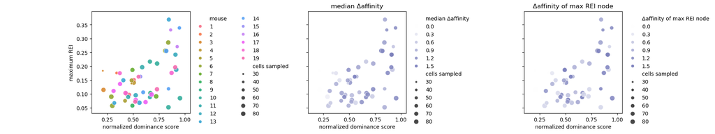

```
d20
```

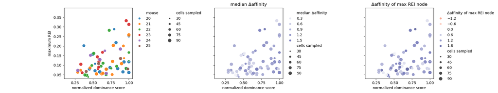

```python
df
```

df

|  | index | uid | τ | ngs_id | mouse | GC | time | cells sampled | normalized dominance score | maximum REI | max Δaffinity | 95th percentile Δaffinity | mean Δaffinity | median Δaffinity | id of max REI node | mutations in max REI node | Δaffinity of max REI node | ΔΔaffinity of max REI node | max REI node is root |
| --- | --- | --- | --- | --- | --- | --- | --- | --- | --- | --- | --- | --- | --- | --- | --- | --- | --- | --- | --- |
| 0 | 1166 | D20_M22_GC96 | 0.5 | PR-1-07 | 22 | 96 | d20 | 39.0 | 0.435897 | 0.038462 | 1.85465 | 1.700965 | 1.005091 | 1.161450 | seq4 | Y88(H)F A105(H)G N108(L)K | 1.35896 | 0.05302 | False |
| 1 | 1159 | D20_M22_GC89 | 0.5 | PR-1-03 | 22 | 89 | d20 | 87.0 | 0.413793 | 0.047593 | 1.83375 | 1.545630 | 0.782702 | 0.714810 | seq33 | Y103(H)F F10(L)L S12(L)T Y42(L)H N108(L)K L116... | 1.46106 | 0.99422 | False |
| 2 | 1158 | D20_M22_GC88 | 0.5 | PR-1-03 | 22 | 88 | d20 | 82.0 | 0.390244 | 0.048780 | 1.96522 | 1.552431 | 0.109996 | 0.138920 | seq15 | T96(H)A P72(L)S N93(L)T L99(L)M L116(L)P | 0.08799 | 0.07656 | False |
| 3 | 1156 | D20_M22_GC86 | 0.5 | PR-1-02 | 22 | 86 | d20 | 76.0 | 0.684211 | 0.050164 | 2.22660 | 1.989688 | 0.534087 | 0.812585 | seq29 | I76(H)F L99(L)W L116(L)P | -0.02546 | 0.00067 | False |
| 4 | 1146 | D20_M21_GC76 | 0.5 | PR-1-05 | 21 | 76 | d20 | 69.0 | 0.768116 | 0.050767 | 2.12465 | 1.787844 | 0.497640 | 1.008670 | 11 | A105(H)G A40(L)G | 1.25043 | 0.00000 | False |
| ... | ... | ... | ... | ... | ... | ... | ... | ... | ... | ... | ... | ... | ... | ... | ... | ... | ... | ... | ... |
| 114 | 1176 | D20_M23_GC106 | 0.5 | PR-1-04 | 23 | 106 | d20 | 83.0 | 1.000000 | 0.312688 | 1.41209 | 1.081766 | 0.828434 | 0.957790 | seq12 | S64(H)T N92(H)K Y42(L)C N108(L)H | 0.95779 | -0.02745 | False |
| 115 | 1110 | D15_M16_GC40 | 0.5 | PR-2-04 | 16 | 40 | d15 | 51.0 | 0.862745 | 0.331189 | 1.90813 | 1.403847 | 0.866527 | 1.199390 | seq13 | A105(H)G Y66(L)F S109(L)R | 1.19939 | 0.75310 | False |
| 116 | 1173 | D20_M23_GC103 | 0.5 | PR-1-03 | 23 | 103 | d20 | 81.0 | 0.962963 | 0.332031 | 1.92757 | 1.245264 | 0.520700 | 0.411910 | seq12 | I78(H)L N92(H)T Y42(L)C | 0.35030 | 0.35030 | False |
| 117 | 1105 | D15_M14_GC35 | 0.5 | PR-2-03 | 14 | 35 | d15 | 57.0 | 0.947368 | 0.338584 | 2.35414 | 2.071883 | 1.101941 | 1.250430 | seq7 | A105(H)G A40(L)G | 1.25043 | 0.80414 | False |
| 118 | 1101 | D15_M13_GC31 | 0.5 | PR-2-03 | 13 | 31 | d15 | 72.0 | 0.845070 | 0.368842 | 1.80017 | 1.484965 | 0.820345 | 0.919910 | seq1 | I78(H)F Y42(L)S N108(L)K | 0.91991 | 0.91991 | False |

119 rows × 19 columns

```python
time_df.round(2)
```

time_df.round(2)

|  | index | uid | τ | ngs_id | mouse | GC | time | cells sampled | normalized dominance score | maximum REI | max Δaffinity | 95th percentile Δaffinity | mean Δaffinity | median Δaffinity | id of max REI node | mutations in max REI node | Δaffinity of max REI node | ΔΔaffinity of max REI node | max REI node is root |
| --- | --- | --- | --- | --- | --- | --- | --- | --- | --- | --- | --- | --- | --- | --- | --- | --- | --- | --- | --- |
| 0 | 1166 | D20_M22_GC96 | 0.5 | PR-1-07 | 22 | 96 | d20 | 39.0 | 0.44 | 0.04 | 1.85 | 1.70 | 1.01 | 1.16 | seq4 | Y88(H)F A105(H)G N108(L)K | 1.36 | 0.05 | False |
| 1 | 1159 | D20_M22_GC89 | 0.5 | PR-1-03 | 22 | 89 | d20 | 87.0 | 0.41 | 0.05 | 1.83 | 1.55 | 0.78 | 0.71 | seq33 | Y103(H)F F10(L)L S12(L)T Y42(L)H N108(L)K L116... | 1.46 | 0.99 | False |
| 2 | 1158 | D20_M22_GC88 | 0.5 | PR-1-03 | 22 | 88 | d20 | 82.0 | 0.39 | 0.05 | 1.97 | 1.55 | 0.11 | 0.14 | seq15 | T96(H)A P72(L)S N93(L)T L99(L)M L116(L)P | 0.09 | 0.08 | False |
| 3 | 1156 | D20_M22_GC86 | 0.5 | PR-1-02 | 22 | 86 | d20 | 76.0 | 0.68 | 0.05 | 2.23 | 1.99 | 0.53 | 0.81 | seq29 | I76(H)F L99(L)W L116(L)P | -0.03 | 0.00 | False |
| 4 | 1146 | D20_M21_GC76 | 0.5 | PR-1-05 | 21 | 76 | d20 | 69.0 | 0.77 | 0.05 | 2.12 | 1.79 | 0.50 | 1.01 | 11 | A105(H)G A40(L)G | 1.25 | 0.00 | False |
| ... | ... | ... | ... | ... | ... | ... | ... | ... | ... | ... | ... | ... | ... | ... | ... | ... | ... | ... | ... |
| 109 | 1141 | D20_M21_GC71 | 0.5 | PR-1-02 | 21 | 71 | d20 | 88.0 | 1.00 | 0.26 | 1.94 | 1.44 | 0.79 | 0.99 | seq11 | R67(L)K Q105(L)H L116(L)I | 0.99 | -0.01 | False |
| 111 | 1161 | D20_M22_GC91 | 0.5 | PR-1-06 | 22 | 91 | d20 | 77.0 | 0.73 | 0.28 | 2.50 | 1.77 | 0.85 | 1.49 | seq17 | Y66(L)H Q105(L)H N108(L)K L116(L)I | 1.64 | 0.49 | False |
| 113 | 1139 | D20_M20_GC69 | 0.5 | PR-1-08 | 20 | 69 | d20 | 54.0 | 0.80 | 0.29 | 2.48 | 2.27 | 0.99 | 1.71 | seq2 | A105(H)G A40(L)G S109(L)R | 2.05 | 0.80 | False |
| 114 | 1176 | D20_M23_GC106 | 0.5 | PR-1-04 | 23 | 106 | d20 | 83.0 | 1.00 | 0.31 | 1.41 | 1.08 | 0.83 | 0.96 | seq12 | S64(H)T N92(H)K Y42(L)C N108(L)H | 0.96 | -0.03 | False |
| 116 | 1173 | D20_M23_GC103 | 0.5 | PR-1-03 | 23 | 103 | d20 | 81.0 | 0.96 | 0.33 | 1.93 | 1.25 | 0.52 | 0.41 | seq12 | I78(H)L N92(H)T Y42(L)C | 0.35 | 0.35 | False |

67 rows × 19 columns

```python
cmap = "viridis"

vmin = min(getattr(node, stat) for tree in trees.values() for node in tree.tree.traverse())
vmax = max(getattr(node, stat) for tree in trees.values() for node in tree.tree.traverse())

for time, time_df in df.groupby("time"):

    scatter_plot = alt.Chart(time_df.round(3)).mark_circle().encode(
        x=alt.X('normalized dominance score:Q', title='Normalized Dominance Score'),
        y=alt.Y('maximum REI:Q', title='Maximum REI'),
        size=alt.Size('cells sampled:Q', title='Cells Sampled'),
        color=alt.Color('mouse:N', title='Mouse', legend=None),
        tooltip=['uid:N', 'cells sampled:Q', 'median Δaffinity:Q', 'Δaffinity of max REI node:Q']  # Tooltip to show the uid when hovered over
    ).properties(
        width=600,
        height=400,
        title='Interactive plot'
    ).interactive()

    # Display the plot
    scatter_plot.show()
    scatter_plot.save(f"{output_dir}/interactive_REI_Dom_{time}.html")
```

cmap = "viridis" vmin = min(getattr(node, stat) for tree in trees.values() for node in tree.tree.traverse()) vmax = max(getattr(node, stat) for tree in trees.values() for node in tree.tree.traverse()) for time, time_df in df.groupby("time"): scatter_plot = alt.Chart(time_df.round(3)).mark_circle().encode( x=alt.X('normalized dominance score:Q', title='Normalized Dominance Score'), y=alt.Y('maximum REI:Q', title='Maximum REI'), size=alt.Size('cells sampled:Q', title='Cells Sampled'), color=alt.Color('mouse:N', title='Mouse', legend=None), tooltip=['uid:N', 'cells sampled:Q', 'median Δaffinity:Q', 'Δaffinity of max REI node:Q'] # Tooltip to show the uid when hovered over ).properties( width=600, height=400, title='Interactive plot' ).interactive() # Display the plot scatter_plot.show() scatter_plot.save(f"{output_dir}/interactive_REI_Dom_{time}.html")

[interactive chart not shown]

```python
# !rm {output_dir}/trees/*.svg
```

# !rm {output_dir}/trees/*.svg

```python
output_dir
```

output_dir

```
'./default'
```

```python
!mkdir -p {output_dir}/trees
```

!mkdir -p {output_dir}/trees

```python
%env MPLBACKEND=Agg
# %matplotlib inline
```

%env MPLBACKEND=Agg # %matplotlib inline

```
env: MPLBACKEND=Agg
```

```python
from collections import defaultdict
tree_expr = defaultdict(list)
for i, row in df.iterrows():
    key = row.uid
    for node in trees[key].tree.traverse():
        tree_expr["uid"].append(key)
        tree_expr["node_bind"].append(getattr(node, "delta_bind"))
        tree_expr["node_expr"].append(getattr(node, "delta_expr"))
        # tree_expr["node_bind_norm"].append(pc.affinity_trees_grey_centered.norm(getattr(node, "delta_bind")))
        # tree_expr["node_expr_norm"].append(pc.expression_trees_grey_centered.norm(getattr(node, "delta_expr")))
tree_expr_df = pd.DataFrame(tree_expr)
tree_expr_df.head()
```

from collections import defaultdict tree_expr = defaultdict(list) for i, row in df.iterrows(): key = row.uid for node in trees[key].tree.traverse(): tree_expr["uid"].append(key) tree_expr["node_bind"].append(getattr(node, "delta_bind")) tree_expr["node_expr"].append(getattr(node, "delta_expr")) # tree_expr["node_bind_norm"].append(pc.affinity_trees_grey_centered.norm(getattr(node, "delta_bind"))) # tree_expr["node_expr_norm"].append(pc.expression_trees_grey_centered.norm(getattr(node, "delta_expr"))) tree_expr_df = pd.DataFrame(tree_expr) tree_expr_df.head()

|  | uid | node_bind | node_expr |
| --- | --- | --- | --- |
| 0 | D20_M22_GC96 | 0.00000 | 0.00000 |
| 1 | D20_M22_GC96 | -0.46711 | -0.30968 |
| 2 | D20_M22_GC96 | 0.48156 | -0.07432 |
| 3 | D20_M22_GC96 | 0.15592 | -0.54128 |
| 4 | D20_M22_GC96 | 0.80414 | 0.03813 |

```python
fig, ax = plt.subplots(2, 1, figsize = [20,10], sharex=True, sharey=True)
sns.boxplot(tree_expr_df, x="uid", y="node_bind", ax=ax[0])
sns.boxplot(tree_expr_df, x="uid", y="node_expr", ax=ax[1])
ax[1].set_xticks(ax[1].get_xticks(), ax[1].get_xticklabels(), rotation=90, ha='right')
plt.show()
```

fig, ax = plt.subplots(2, 1, figsize = [20,10], sharex=True, sharey=True) sns.boxplot(tree_expr_df, x="uid", y="node_bind", ax=ax[0]) sns.boxplot(tree_expr_df, x="uid", y="node_expr", ax=ax[1]) ax[1].set_xticks(ax[1].get_xticks(), ax[1].get_xticklabels(), rotation=90, ha='right') plt.show()

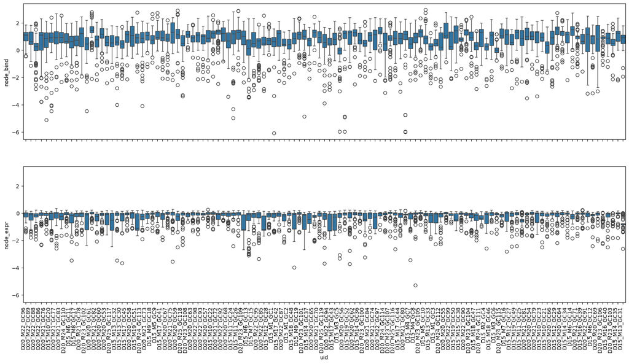

```python
branch_margin = 0.1
# scale = 20
for i, row in df.iterrows():
    x, y = row[["normalized dominance score", f"maximum {stat}"]]
    key = row.uid

    colormap1 = trees[key].feature_colormap(
        stat,
        vmin=vmin,
        vmax=vmax,
        # scale="symlog",
        linthresh=1,
        cmap=cmap
    )
    trees[key].render(
        f"{output_dir}/trees/{key}.{stat}.scale{scale}.svg",
        colormap=colormap1,
        scale=scale,
        branch_margin=branch_margin
    )
    # print(f"Done: {key}")
    # if row[f"maximum {stat}"] > thresh:
    #     print(row.uid, stat)
    #     if row[f"max {stat} node is root"]:
    #         print(f"NOTE: max {stat} node is root")
    #     display(
    #         trees[key].render(
    #             "%%inline",
    #             colormap=colormap1,
    #             scale=scale,
    #             branch_margin=branch_margin
    #         )
    #     )

    colormap2 = {
        node.name: to_hex(
            pc.affinity_trees_grey_centered.cmap(
                pc.affinity_trees_grey_centered.norm(
                    getattr(node, "delta_bind")
                )
            )
        ) for node in trees[key].tree.traverse()
    }
    trees[key].render(
        f"{output_dir}/trees/{key}.binding.scale{scale}.svg",
        colormap=colormap2,
        scale=scale,
        branch_margin=branch_margin
    )
    # if row[f"maximum {stat}"] > thresh:
    #     print(row.uid, "Δaffinity")
    #     display(
    #         trees[key].render(
    #             "%%inline",
    #             colormap=colormap2,
    #             scale=scale,
    #             branch_margin=branch_margin
    #         )
    #     )

    colormap3 = {
        node.name: to_hex(
            pc.expression_trees_grey_centered.cmap(
                pc.expression_trees_grey_centered.norm(
                    getattr(node, "delta_expr")
                )
            )
        ) for node in trees[key].tree.traverse()
    }
    trees[key].render(
        f"{output_dir}/trees/{key}.expression.scale{scale}.svg",
        colormap=colormap3,
        scale=scale,
        branch_margin=branch_margin
    )

# plt.show()
```

branch_margin = 0.1 # scale = 20 for i, row in df.iterrows(): x, y = row[["normalized dominance score", f"maximum {stat}"]] key = row.uid colormap1 = trees[key].feature_colormap( stat, vmin=vmin, vmax=vmax, # scale="symlog", linthresh=1, cmap=cmap ) trees[key].render( f"{output_dir}/trees/{key}.{stat}.scale{scale}.svg", colormap=colormap1, scale=scale, branch_margin=branch_margin ) # print(f"Done: {key}") # if row[f"maximum {stat}"] > thresh: # print(row.uid, stat) # if row[f"max {stat} node is root"]: # print(f"NOTE: max {stat} node is root") # display( # trees[key].render( # "%%inline", # colormap=colormap1, # scale=scale, # branch_margin=branch_margin # ) # ) colormap2 = { node.name: to_hex( pc.affinity_trees_grey_centered.cmap( pc.affinity_trees_grey_centered.norm( getattr(node, "delta_bind") ) ) ) for node in trees[key].tree.traverse() } trees[key].render( f"{output_dir}/trees/{key}.binding.scale{scale}.svg", colormap=colormap2, scale=scale, branch_margin=branch_margin ) # if row[f"maximum {stat}"] > thresh: # print(row.uid, "Δaffinity") # display( # trees[key].render( # "%%inline", # colormap=colormap2, # scale=scale, # branch_margin=branch_margin # ) # ) colormap3 = { node.name: to_hex( pc.expression_trees_grey_centered.cmap( pc.expression_trees_grey_centered.norm( getattr(node, "delta_expr") ) ) ) for node in trees[key].tree.traverse() } trees[key].render( f"{output_dir}/trees/{key}.expression.scale{scale}.svg", colormap=colormap3, scale=scale, branch_margin=branch_margin ) # plt.show()

## Color bars for the tree colormaps

```python
fig = plt.figure(figsize=(2, 1))
cax = fig.add_axes([0, 0, 1, 0.1])
plt.colorbar(cm.ScalarMappable(cmap=cmap, norm=Normalize(vmin=vmin, vmax=vmax)),
             orientation='horizontal',
             cax=cax,
             label=f"{stat}")
plt.savefig(f"{output_dir}/cbar_REI.svg", bbox_inches="tight")
plt.show()

fig = plt.figure(figsize=(2, 1))
cax = fig.add_axes([0, 0, 1, 0.1])
plt.colorbar(cm.ScalarMappable(cmap=pc.affinity_trees_grey_centered.cmap, norm=pc.affinity_trees_grey_centered.norm),
             orientation='horizontal',
             cax=cax,
             label="Δaffinity")
plt.savefig(f"{output_dir}/cbar_binding.svg", bbox_inches="tight")
plt.show()

fig = plt.figure(figsize=(2, 1))
cax = fig.add_axes([0, 0, 1, 0.1])
plt.colorbar(
    cm.ScalarMappable(
        cmap=pc.expression_trees_grey_centered.cmap,
        norm=pc.expression_trees_grey_centered.norm
    ),
    orientation='horizontal',
    cax=cax,
    label="Δexpression",
    ticks=[-3, 0, 1],

    )
plt.savefig(f"{output_dir}/cbar_expression.svg", bbox_inches="tight")
plt.show()
```

[output not shown]

fig = plt.figure(figsize=(2, 1)) cax = fig.add_axes([0, 0, 1, 0.1]) plt.colorbar(cm.ScalarMappable(cmap=cmap, norm=Normalize(vmin=vmin, vmax=vmax)), orientation='horizontal', cax=cax, label=f"{stat}") plt.savefig(f"{output_dir}/cbar_REI.svg", bbox_inches="tight") plt.show() fig = plt.figure(figsize=(2, 1)) cax = fig.add_axes([0, 0, 1, 0.1]) plt.colorbar(cm.ScalarMappable(cmap=pc.affinity_trees_grey_centered.cmap, norm=pc.affinity_trees_grey_centered.norm), orientation='horizontal', cax=cax, label="Δaffinity") plt.savefig(f"{output_dir}/cbar_binding.svg", bbox_inches="tight") plt.show() fig = plt.figure(figsize=(2, 1)) cax = fig.add_axes([0, 0, 1, 0.1]) plt.colorbar( cm.ScalarMappable( cmap=pc.expression_trees_grey_centered.cmap, norm=pc.expression_trees_grey_centered.norm ), orientation='horizontal', cax=cax, label="Δexpression", ticks=[-3, 0, 1], ) plt.savefig(f"{output_dir}/cbar_expression.svg", bbox_inches="tight") plt.show()

## Stack the tree svg's into a single image

define output directory and clear out any existing files

```python
stacked_dir = f"{output_dir}/stacked_trees"
!mkdir -p {stacked_dir}
!rm {output_dir}/stacked_trees/ngs_id*{scale}*.svg
```

stacked_dir = f"{output_dir}/stacked_trees" !mkdir -p {stacked_dir} !rm {output_dir}/stacked_trees/ngs_id*{scale}*.svg

```
rm: cannot remove './default/stacked_trees/ngs_id*20*.svg': No such file or directory
```

```python
# Set the maximum width for the display
pd.set_option('display.max_colwidth', None)

# Set the maximum number of columns to display
pd.set_option('display.max_columns', None)
```

# Set the maximum width for the display pd.set_option('display.max_colwidth', None) # Set the maximum number of columns to display pd.set_option('display.max_columns', None)

Use svg utils to stitch together the trees rendered above.

```python
for stat in ["REI", "binding", "expression"]:
    for duration in ["20", "15"]:

        files = sorted(glob.glob(f"{output_dir}/trees/D{duration}*{stat}.scale{scale}.svg"))
        files_df = pd.DataFrame(files, columns=["file"])
        path_start = 0 if not files[0].startswith(".") else 1
        files_df["UID"] = files_df.file.str.split(".").str[path_start].str.split("/").str[-1]
        files_df["mouse"] = files_df.file.str.extract(r"M(\d+)").astype(int)
        files_df["GC"] = files_df.file.str.extract(r"GC(\d+)").astype(int)
        files_df.sort_values(["mouse", "GC"], inplace=True)

        # Initial y position for stacking
        y_offset = 220
        all_panels = []
        all_panels.append(
           Text(f"IMM Duration: {duration} days", 200, 35, size=24, weight='bold')
        )

        # add colorbar
        cbar = f"cbar_{stat}"
        colorbar_svg = SVG(f"{output_dir}/{cbar}.svg").scale(2)
        colorbar_svg.move(175, 45)
        all_panels.append(colorbar_svg)

        # iterate through the tree, create a panel for each one.
        for i, (idx, row) in enumerate(files_df.iterrows()):

            position = (10, y_offset)
            annotation = row.UID
            panel = Panel(
                    SVG(row.file).scale(0.5),
                    Text(annotation, 10, -20, size=16, weight='bold')
            ).move(*position)
            all_panels.append(panel)
            if scale == 20:
                y_offset += 350
            else:
                y_offset += 125

        fig = Figure("%dpx"%1050, "%dpx" % y_offset ,*all_panels)
        fig.save(f"{output_dir}/stacked_trees/D{duration}.{stat}.scale{scale}.svg")
```

for stat in ["REI", "binding", "expression"]: for duration in ["20", "15"]: files = sorted(glob.glob(f"{output_dir}/trees/D{duration}*{stat}.scale{scale}.svg")) files_df = pd.DataFrame(files, columns=["file"]) path_start = 0 if not files[0].startswith(".") else 1 files_df["UID"] = files_df.file.str.split(".").str[path_start].str.split("/").str[-1] files_df["mouse"] = files_df.file.str.extract(r"M(\d+)").astype(int) files_df["GC"] = files_df.file.str.extract(r"GC(\d+)").astype(int) files_df.sort_values(["mouse", "GC"], inplace=True) # Initial y position for stacking y_offset = 220 all_panels = [] all_panels.append( Text(f"IMM Duration: {duration} days", 200, 35, size=24, weight='bold') ) # add colorbar cbar = f"cbar_{stat}" colorbar_svg = SVG(f"{output_dir}/{cbar}.svg").scale(2) colorbar_svg.move(175, 45) all_panels.append(colorbar_svg) # iterate through the tree, create a panel for each one. for i, (idx, row) in enumerate(files_df.iterrows()): position = (10, y_offset) annotation = row.UID panel = Panel( SVG(row.file).scale(0.5), Text(annotation, 10, -20, size=16, weight='bold') ).move(*position) all_panels.append(panel) if scale == 20: y_offset += 350 else: y_offset += 125 fig = Figure("%dpx"%1050, "%dpx" % y_offset ,*all_panels) fig.save(f"{output_dir}/stacked_trees/D{duration}.{stat}.scale{scale}.svg")

# Affinity vs. REI

```python
stat = "REI"
dat = []
for gc, tree in trees.items():
    for node in tree.tree.traverse():
        dat.append([gc, getattr(node, stat), node.delta_bind])

df_nodes = pd.DataFrame(dat, columns=["GC", stat, "Δaffinity"])

plt.figure(figsize=(4, 4))
sns.scatterplot(data=df_nodes, x=stat, y="Δaffinity", hue="GC", legend=False, alpha=0.5, size=.1)
plt.axhline(0, ls="--", c="k", lw=1)
plt.axvline(0, ls="--", c="k", lw=1)
plt.xscale("log")
plt.tight_layout()
plt.show()
```

stat = "REI" dat = [] for gc, tree in trees.items(): for node in tree.tree.traverse(): dat.append([gc, getattr(node, stat), node.delta_bind]) df_nodes = pd.DataFrame(dat, columns=["GC", stat, "Δaffinity"]) plt.figure(figsize=(4, 4)) sns.scatterplot(data=df_nodes, x=stat, y="Δaffinity", hue="GC", legend=False, alpha=0.5, size=.1) plt.axhline(0, ls="--", c="k", lw=1) plt.axvline(0, ls="--", c="k", lw=1) plt.xscale("log") plt.tight_layout() plt.show()

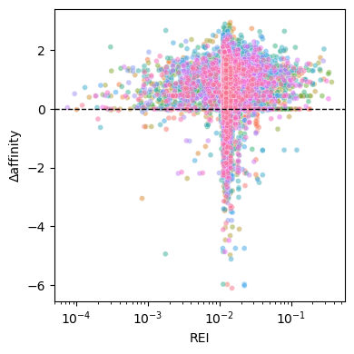

## Summary

- Developed REI, because no branch lengths with LB
- Doesn't correlate will with GC affinity
- Recent motivated by evolving affinity